# 01-covariance_centering

Corson N. Areshenkoff

18/03/2022

## Required packages

```r
library(plyr)

# Used for covariance estimation and centering
library(spdm)

# Used for visualizing the results of centering
library(proxy)
library(ggplot2)
```

## Data

The file `data/guides/example_data.rds` contains example BOLD data from 4 subjects, each with rest and task scans. The data are stored in a dataframe with columns for `Subject`, `Scan`, and `Data`; the latter containing TR x ROI matrices of (standardized) BOLD data.

```r
df <- readRDS('../data/example_data.rds')
```

## Workflow

### Covariance estimation

The library `spdm` implements several forms of covariance estimation though `spd.estimate()`, but the linear shrinkage estimator `linshrink` is a reasonable default choice. In small sample settings (when the number of observations is not large relative to the number of variables) the sample covariance is particularly poor, and may not even be positive-definite, but regularized estimators typically perform better even with large samples.

We can estimate covariance matrices for all scans in one pass with

```
lapply(df$Data, spd.estimate, method = 'linshrink')
```

but as covariance estimates are biased, and this bias depends on the sample size, it is generally better to ensure an equal number of observations in each condition to avoid systematic bias when scan lengths differ. For regularized covariance estimates, this is true because the shrinkage penalty is generally a function of the sample size. But note that this is true even for the sample covariance, which is biased under the natural metric on the space of covariance matrices.

Unless one is interested in a particular phase of the task (e.g. early or late), a simple approach might be to subsample the longer scans. We can choose a number of observations equal to the shortest scan (the resting scans):

```r
n.samples <- min(sapply(df$Data, nrow))
n.samples
```

```
## [1] 177
```

We can then estimate the covariance over 177 equally spaced observations in each scan:

```r
df$Cov <- lapply(df$Data, function(d) {
    idx <- round(seq(1, nrow(d), length.out = n.samples))
    spd.estimate(d[idx,], method = 'linshrink')
})
```

### Visualizing subject level clustering

A low-dimensional embedding of the covariance matrices can be useful for visualizing the success of centering. We typically use umap, but other groups (e.g. the midnight scan club) have used approaches such as multidimensional scaling with similar results. In this example, with such a small number of observations, we use MDS.

Since our goal is to respect the natural geometry of the space of covariance matrices as much as possible, we perform the embedding using a distance matrix calculated using the intrinsic (geodesic) distance between covariance matrices.

This can be done using the function `spd.dist`. Right now (as of the date listed above) this function is limited to computing the distance between a single pair of covariance matrices, and so the full distance matrix must be constructed manually, or using the `dist` function provided in the `proxy` library. Note that the distance measure we use (`riemannian`) can be quite slow in high-dimensions, so for large datasets with many ROIs, this can take some time.

```r
distance.uncentered <- proxy::dist(df$Cov, method = function(i,j) {
    spd.dist(i, j, method = 'riemannian')
})
```

MDS can then be performed on the distance matrix to obtain a 2-dimensional embedding. Note the subject level clustering.

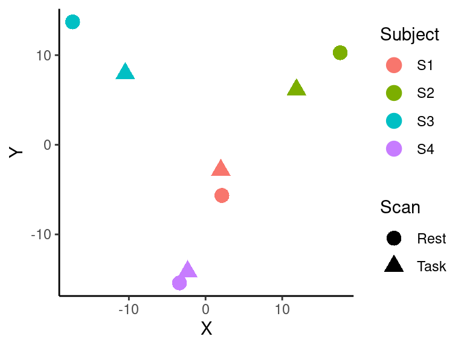

```r
mds.uncentered <- cmdscale(distance.uncentered)
pf.mds.uncentered <- data.frame(Subject = df$Subject, Scan = df$Scan,
                                X = mds.uncentered[,1],
                                Y = mds.uncentered[,2])
ggplot(pf.mds.uncentered,
       aes(x = X, y = Y, color = Subject, shape = Scan)) +
    theme_classic() + geom_point(size = 4)
```

### Centering

The goal of centering is to account for baseline differences in subject functional connectivity. For example, we might want to account for overall mean subject difference, or differences during resting state or a baseline phase of a task. In this case, we’ll mean-center the four subjects. The general workflow is as follows:

```
1. Compute the mean covariance for each subject
2. Compute the grand mean covariance
3. Translate each subject's covariance matrices from the subject mean to the
grand mean
```

Means can be computing using `spd.mean()`, where we set `method = 'riemannian'` to compute the mean in the space of covariance matrices. We do this for each subject, and over all subjects.

```r
grand.mean <- spd.mean(df$Cov, method = 'riemannian')
subject.means <- ddply(df, 'Subject', summarize,
                       'Cov' = list(spd.mean(Cov, method = 'riemannian')))
```

To perform the translation, we first project each covariance matrix onto the tangent space at the corresponding subject mean. We then parallel transport these vectors to the grand mean, and project back onto the space of covariance matrices. These steps can be done, respectively, using the `spd.logmap`, `spd.transport`, and `spd.expmap` functions. Alternatively, they can be done in a single call to the `spd.translate` function.

At the moment, `spdm` lacks a convenient wrapper for centering entire datasets, and so this must be done for each subject.

```r
df$CovCen <- lapply(1:nrow(df), function(i) {
    cov.mat <- df$Cov[[i]]
    sub.mean <- subset(subject.means, Subject == df$Subject[i])$Cov[[1]]
    cov.mat.cen <- spd.translate(cov.mat, from = sub.mean, to = grand.mean)
    return(cov.mat.cen)
})
```

The work of `spd.translate` can be done manually as follows:

```
df$CovCen <- lapply(1:nrow(df), function(i) {
    cov.mat <- df$Cov[[i]]
    sub.mean <- subset(subject.means, Subject == df$Subject[i])$Cov[[1]]

    # Project observed covariance onto the tangent space around
    # the subject mean
    tanvec <- spd.logmap(cov.mat, p = sub.mean)

    # Transport the tangent vector to the tangent space at the grand mean
    tanvec.gm <- spd.transport(tanvec, from = sub.mean, to = grand.mean)

    # Project the transported tangent vector back to the space of
    covariance matrices
    cov.mat.cen <- spd.expmap(tanvec.gm, p = grand.mean)

    return(cov.mat.cen)
})
```

We may also want to represent the centered covariance matrices as tangent vectors at the grand mean, since these more purely encode *differences* relative to the mean. These can be extracted by projecting the centered covariance matrices back onto the tangent space at the grand mean:

```r
df$TanVec <- lapply(df$CovCen, spd.logmap, p = grand.mean)
```

### Visualizing the effects of centering

We can now follow essentially the same procedure as before to perform MDS on the centered covariance matrices.

```r
distance.centered <- proxy::dist(df$CovCen, method = function(i,j) {
    spd.dist(i, j, method = 'riemannian')
})
```

MDS can then be performed on the distance matrix to obtain a 2-dimensional embedding. Note that the subject level clustering has disappeared, and the first component (x) now clearly encodes the difference between rest and task.

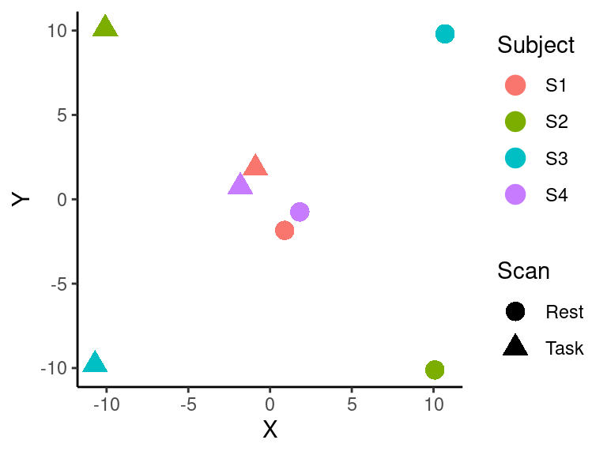

```r
mds.centered <- cmdscale(distance.centered)
pf.mds.centered <- data.frame(Subject = df$Subject, Scan = df$Scan,
                              X = mds.centered[,1],
                              Y = mds.centered[,2])
ggplot(pf.mds.centered,
       aes(x = X, y = Y, color = Subject, shape = Scan)) +
    theme_classic() + geom_point(size = 4)
```

### Output

```r
saveRDS(df, file = '../data/output_01-covariance_centering.rds')
```